# hateLess Program: Student Profile Cluster Analysis

Magnus Research Team

March 14, 2025

# 1 Executive Summary

This report presents the results of a cluster analysis performed on the hateLess program dataset. Using psychosocial factors as clustering variables, we identified three distinct student profiles with different patterns of hate speech experiences. The analysis reveals important relationships between classroom climate, empathy, self-efficacy, and hate speech behaviors that can inform targeted interventions.

# 2 Introduction

The hateLess program aims to reduce hate speech and improve classroom climate in schools. Understanding different student profiles can help tailor interventions to specific needs. This analysis used k-means clustering to identify natural groupings of students based on their psychosocial characteristics.

# 3 Methodology

## 3.1 Data and Variables

- **Empathy score**: Composite measure of empathy-related items
- **Self-efficacy score**: Composite measure of self-efficacy items
- **Positive climate**: Composite measure of positive classroom climate (inclusivity, acceptance, etc.)
- **Negative climate**: Composite measure of negative classroom climate (violence, teasing, etc.)

## 3.2 Clustering Approach

K-means clustering was applied to scaled versions of the four psychosocial variables. The optimal number of clusters was determined using the silhouette method, which measures how similar an object is to its own cluster compared to other clusters.

[figure not shown]

# 4 Results

## 4.1 Identified Clusters

The analysis identified three distinct clusters of students with the following characteristics:

Psychosocial characteristics of identified clusters

| Cluster | Number of Students | Empathy Score | Self-Efficacy Score | Positive Climate | Negative Climate |
| --- | --- | --- | --- | --- | --- |
| 1 | 238 | 2.83 | 2.82 | 3.40 | 2.10 |
| 2 | 170 | 1.67 | 1.54 | 2.93 | 2.04 |
| 3 | 178 | 2.77 | 2.44 | 2.29 | 3.05 |

## 4.2 Cluster Visualization

The following plot shows how the three clusters are distributed across the first two principal components derived from the four clustering variables:

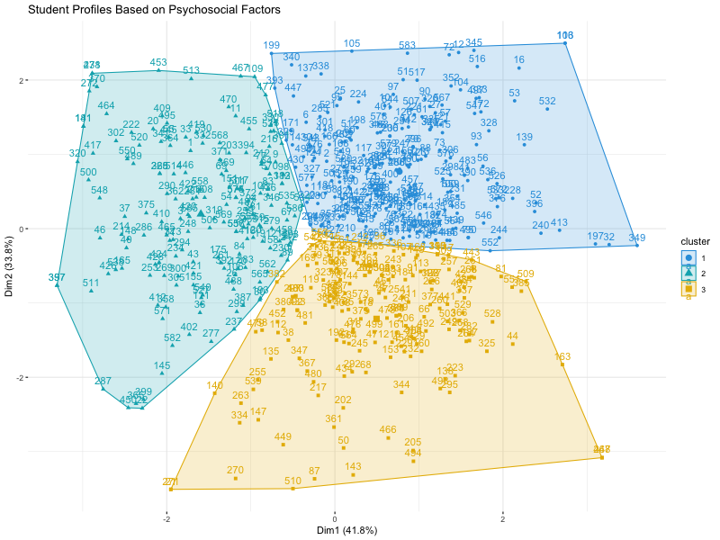

Visualization of the three student clusters based on psychosocial factors

## 4.3 Hate Speech Experiences by Cluster

We examined how hate speech experiences differed across the three clusters:

Hate speech experiences by cluster (percentage)

| Cluster | Victim (Class) % | Witness (Class) % | Perpetrator (Class) % | Victim (Online) % | Witness (Online) % | Perpetrator (Online) % |
| --- | --- | --- | --- | --- | --- | --- |
| 1 | 40.3 | 68.2 | 12.8 | 18.6 | 52.9 | 3.4 |
| 2 | 36.3 | 67.9 | 19.9 | 15.9 | 53.5 | 13.5 |
| 3 | 62.5 | 89.8 | 26.7 | 31.4 | 63.2 | 14.3 |

The following visualization shows the differences in hate speech experiences across clusters:

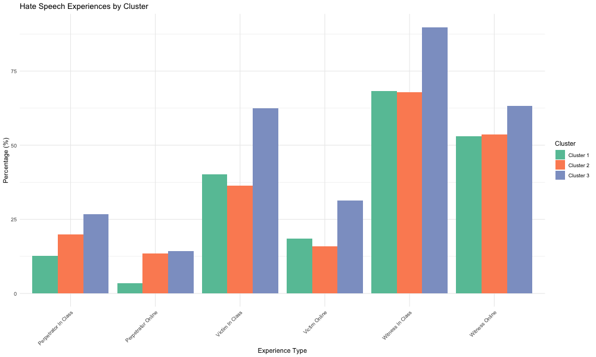

Hate speech experiences by cluster

# 5 Cluster Profiles

Based on the analysis, we can characterize the three clusters as follows:

## 5.1 Cluster 1: “Positive Environment Students” (n=238)

**Psychosocial characteristics:** - Highest positive climate scores (3.4) - Lowest negative climate scores (2.1) - High empathy (2.83) and self-efficacy (2.82)

**Hate speech experiences:** - Moderate victimization in class (40.3%) - Lower perpetration rates (12.8% in class) - Lower online victimization (18.6%)

## 5.2 Cluster 2: “Disengaged Students” (n=170)

**Psychosocial characteristics:** - Lowest empathy scores (1.67) - Lowest self-efficacy scores (1.54) - Moderate positive climate (2.93) - Low negative climate (2.04)

**Hate speech experiences:** - Lowest victimization rates in class (36.3%) - Higher perpetration rates than Cluster 1 (19.9%)

## 5.3 Cluster 3: “High-Risk Students” (n=178)

**Psychosocial characteristics:** - Highest negative climate scores (3.05) - Lowest positive climate scores (2.29) - Moderate empathy (2.77) and self-efficacy (2.44)

**Hate speech experiences:** - Significantly higher victimization rates (62.5% in class, 31.4% online) - Highest perpetration rates (26.7% in class) - Highest witness rates (89.8% in class)

# 6 Discussion

## 6.1 Key Insights

1. **Classroom Climate is Critical**: The cluster with the highest negative climate scores (Cluster 3) shows dramatically higher rates of hate speech victimization, witnessing, and perpetration. This reinforces the importance of classroom climate in hate speech dynamics.
2. **Empathy and Self-Efficacy Matter**: Students with higher empathy and self-efficacy scores (Cluster 1) report lower perpetration rates and experience more positive classroom climates.
3. **Disengaged Students**: Cluster 2 represents a group with low empathy and self-efficacy who are somewhat disconnected from the social dynamics. They report lower victimization rates but higher perpetration than the positive environment students.
4. **Online vs. In-Class Patterns**: All clusters show lower rates of online hate speech compared to in-class experiences, but the relative patterns remain consistent across contexts.

## 6.2 Implications for the hateLess Program

1. **Targeted Interventions**: The program could be tailored differently for each cluster:
   - Cluster 1: Reinforce positive behaviors and climate
   - Cluster 2: Focus on building empathy and self-efficacy
   - Cluster 3: Intensive intervention to improve classroom climate and reduce victimization
2. **Early Identification**: These profiles could help identify high-risk students or classrooms before problems escalate.
3. **Program Evaluation**: Future evaluations could track movement between clusters as a measure of program success.

# 7 Conclusion

This cluster analysis has revealed three distinct student profiles with different psychosocial characteristics and patterns of hate speech experiences. These findings can inform more targeted and effective interventions within the hateLess program. Particularly important is the strong relationship between classroom climate and hate speech behaviors, suggesting that interventions aimed at improving classroom climate may be especially effective in reducing hate speech.

# 8 Appendix: Technical Details

The cluster analysis was performed using k-means clustering with the following parameters: - Number of clusters: 3 - Number of random starts: 25 - Distance measure: Euclidean - Variables were standardized prior to clustering

The between-cluster sum of squares (BSS) and total sum of squares (TSS) ratio, which indicates the percentage of variance explained by the clustering, is 43.9%.